# popularity and loneliness Study 2a Data Analysis

We use groundhog (https://groundhogr.com/) to manage our packages. Groundhog makes sure that our package versions are consistent with the current date. This way, everyone will be using packages from the same date to prevent any issues related to package versioning in future analyses.

To use groundhog, please: (1) make sure that you have the latest version of R/ RStudio installed; (2) install RTools (3) make sure you are in a new R Session

The R Version used to create this file is: `R version 4.3.0 (2023-04-21 ucrt)`. You can change this out with your own version of R if you are using this template to create your own analysis. If you are reproducing another person’s analysis, please download the version of R used by the previous person to ensure a proper reproduction of the code.

You can identify your version of R by typing `version` into the R Console

You can switch your R version by pressing `Tools` > `Global Options` > `R Version`

```r
# if you need to install groundhog
#if(!suppressWarnings(require(groundhog))){remotes::install_github('CredibilityLab/groundhog')}

#call groundhog
library("groundhog")
# put all packages in and call groundhog
pkgs <- c('Rmisc', 'corrplot', 'tidyverse', 'broom.mixed', 'knitr', 'lmerTest', 'Hmisc', 'psych', 'simr', 'future', 'glue', 'sjmisc', 'quanteda', 'wordcloud', 'car', 'DeclareDesign', 'tidytext', 'mediation', 'hrbrthemes', 'MuMIn'
    )

pkgs_all <- c(pkgs)

# call groundhog. Change out the date for today's date (unless you are running an old analysis)
groundhog.library(pkgs_all, "2025-04-09")
```

[output not shown]

```r
#load data
input_dir = "../data/raw/data/"
output_dir = "../data/raw/anonymized-data/"
# df_trial <- read_rds("anonymized-data/df_trial.rds")
df_trial <- read_rds("../data/raw/anonymized-data/df_trial_w_agent_profiles.rds")
nrow(df_trial)/30
```

```
[1] 146
```

```r
d <- read.csv("../data/raw/anonymized-data/df_agent.csv")
all_agents <- read_csv("../data/raw/anonymized-data/all_agents.csv")
qualtrics <- read.csv("../data/raw/anonymized-data/qtrcs_popularity_production.csv")

#modify variables
d$kept = factor(d$kept, labels =c ("eliminated", "kept"))
d$photo_nice = factor(d$photo_nice, labels = c("negative rating", "positive rating"))
d$absDif = abs (d$subject_rating-d$agent_rating)
d$trial = as.numeric(d$trial)
df_trial$trial=as.numeric(df_trial$trial)
d$dif = d$subject_rating-d$agent_rating
d$lonely_cat=factor(d$lonely_cat)
d$lonely_cat=relevel(d$lonely_cat,"low in loneliness")
d$.loneliness = 5-d$.loneliness


#functions
tidy. <- function(df) {
  df %>%
    tidy() %>%
    mutate_if(is.numeric,~round(., 3))
}

barGraph = function (data, outcome,group1,group2,title, xtitle,ytitle){
  dfc=summarySE(data, measurevar=outcome,
                groupvars=c(group1,group2), na.rm = T)
  dfc$high = dfc[,4]+dfc[,7]
  dfc$low = dfc[,4]-dfc[,7]
  pd <- position_dodge(0)
  ggplot(dfc, aes_string(x=group1, y=outcome, fill = group2)) +
      geom_bar(position=position_dodge(), stat="identity", colour="black" ) +
      labs(title="")+
      guides(fill=guide_legend(title=NULL))+
      theme_bw()+
      theme(plot.title = element_text(hjust=0.5,size = rel(1.5)),
            axis.title.y = element_text(face="bold",  size=14),
            axis.text.x  = element_text( vjust=0.5, size=18),
            axis.text.y  = element_text( vjust=0.5, size=12),
            axis.title.x = element_text( vjust=0.5, size=18)) +
    #coord_cartesian(ylim=c(3, 6)) +
    labs(title = title,
         x = xtitle,
         y = ytitle)+
    geom_errorbar(aes(ymin=low, ymax=high),
                    width=.1,position=position_dodge(.9))
}

barGraph2 = function (data, outcome,group1,group2,title, xtitle,ytitle){
  dfc=summarySE(data, measurevar=outcome,
                groupvars=c(group1,group2), na.rm = T)
  dfc$high = dfc[,4]+dfc[,7]
  dfc$low = dfc[,4]-dfc[,7]
  pd <- position_dodge(0)
  ggplot(dfc, aes_string(x=group1, y=outcome, fill = group2)) +
      geom_bar(position=position_dodge(), stat="identity", colour="black" ) +
      labs(title="")+
      guides(fill=guide_legend(title=NULL))+
      theme_bw()+
      coord_cartesian(ylim = c(200, 225)) +
      theme(plot.title = element_text(hjust=0.5,size = rel(1.5)),
            axis.title.y = element_text(face="bold",  size=14),
            axis.text.x  = element_text( vjust=0.5, size=18),
            axis.text.y  = element_text( vjust=0.5, size=12),
            axis.title.x = element_text( vjust=0.5, size=18)) +
    #coord_cartesian(ylim=c(3, 6)) +
    labs(title = title,
         x = xtitle,
         y = ytitle)+
    geom_errorbar(aes(ymin=low, ymax=high),
                    width=.1,position=position_dodge(.9))
}

lineGraph = function (data, outcome,group1,group2,title, xtitle,ytitle){
  dfc=summarySE(data, measurevar=outcome,
                groupvars=c(group1,group2), na.rm = T)
  print(dfc)
  dfc$high = dfc[,4]+dfc[,7]
  dfc$low = dfc[,4]-dfc[,7]
  pd <- position_dodge(0)
  ggplot(dfc,aes_string(x=group2, y=outcome ,fill = group1, colour =group1))+
    geom_errorbar(aes(ymin=low, ymax=high), width=.1)+
    geom_line( aes_string(linetype= group1, group=group1),size = .5)+
    #facet_wrap(as.formula(paste("~", group1)),nrow=2)+
    geom_point()+
    theme_ipsum() +
    scale_color_manual(values=c("#69b3a2", "#404080")) +
    theme(plot.title = element_text(hjust=0.5,size = rel(1.5)),
          axis.title.y = element_text(size=14),
          axis.text.x  = element_text( vjust=0.5, size=14),
          axis.text.y  = element_text( vjust=0.5, size=12),
          axis.title.x = element_text( vjust=0.5, size=14)) +
    labs(title = title,
          x = xtitle,
          y = ytitle)
}


# add age category
d = d %>%
  mutate(age = as.numeric(age)) %>%
  mutate(age_cat = case_when(
    (.$age<=31)==TRUE ~ "18-31",
    (.$age>31)==TRUE ~ "32_plus"))
d[,c("age", "age_cat")]
```

| age | age_cat |
| --- | --- |
| 41 | 32_plus |
| 41 | 32_plus |
| 41 | 32_plus |
| 41 | 32_plus |
| 41 | 32_plus |
| 41 | 32_plus |
| 41 | 32_plus |
| 41 | 32_plus |
| 41 | 32_plus |
| 41 | 32_plus |

[output cut: 990 more lines]

```r
# add political category
d = d %>%
  mutate(political_ideology = as.factor(political_ideology)) %>%
  mutate(politic_cat = case_when(
    (.$political_ideology == "Slightly conservative" | .$political_ideology == "Moderately convservative" | .$political_ideology == "Strong conservative")==TRUE ~ "conservative",
    (.$political_ideology == "Slightly liberal" | .$political_ideology == "Moderate liberal" | .$political_ideology == "Strong liberal")==TRUE ~ "liberal",
    (.$political_ideology == "Neutral") == TRUE ~ "neutral"))
d[,c("political_ideology", "politic_cat")]
```

| political_ideology | politic_cat |
| --- | --- |
| Strong conservative | conservative |
| Strong conservative | conservative |
| Strong conservative | conservative |
| Strong conservative | conservative |
| Strong conservative | conservative |
| Strong conservative | conservative |
| Strong conservative | conservative |
| Strong conservative | conservative |
| Strong conservative | conservative |
| Strong conservative | conservative |

[output cut: 990 more lines]

```r
# how many participants in total
length(unique(d$participant_id))
```

```
[1] 146
```

```r
# add the sign of agents' emotional rating
d = d %>%
  mutate(agent_rating_sign = ifelse(agent_rating >=0, "positive rating", "negative rating"))
d$agent_absRat = abs (d$agent_rating)
d$subject_absRat = abs (d$subject_rating)

# add two table of kept-only and eliminate-only agents
d_kept <- d %>%
      filter(kept == 'kept')
d_eliminate <- d %>%
  filter(kept == 'eliminate')

# add columns of agent comments containing "lonely" and "popular"
d$agent_withlonely = ifelse(grepl("lone",d$agent_response), 1, 0)
d$agent_withpopular = ifelse(grepl("pop", d$agent_response), 1, 0)

# create popularity coefficient
r = glmer(kept ~ agent_liking + (agent_liking | participant_id), family = binomial, data = d)
```

```
boundary (singular) fit: see help('isSingular')
```

[output not shown]

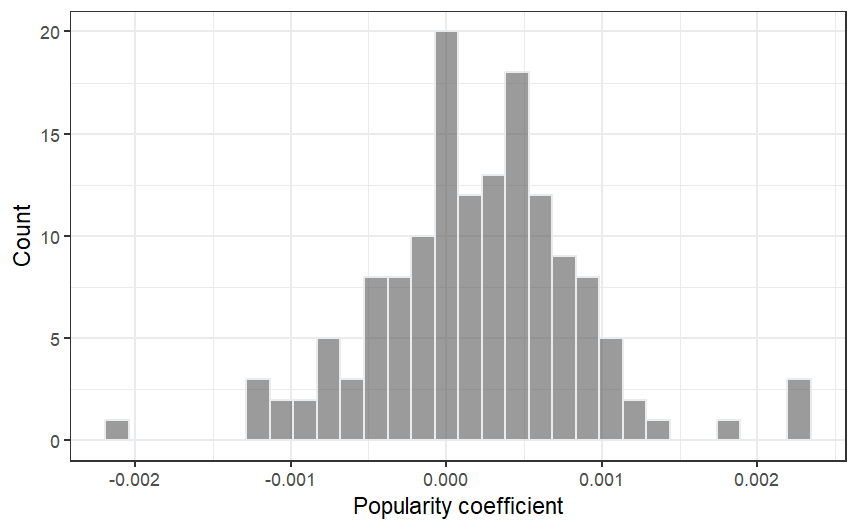

```r
d_coef <- coef(r)$participant_id

d_coef <- d_coef %>%
  rownames_to_column(., "participant_id") %>%
  dplyr::select(participant_id, agent_liking) %>%
  rename(per_person_kept = agent_liking)

p <- d_coef %>%
  ggplot( aes(x=per_person_kept)) +
    theme_bw()+
    geom_histogram( color="#e9ecef", alpha=0.6, , position="dodge") +
    scale_fill_manual(values=c("#69b3a2", "#404080")) +
    #theme_ipsum() +
    labs(x = "Popularity coefficient", y = "Count") ;p
```

```r
nm <- "popularity_coef"
d[nm] <- lapply(nm, function(x) d_coef[["per_person_kept"]][match(d$participant_id, d_coef$participant_id)])
```

### Descriptives

```r
des = d %>%
  group_by(participant_id)%>%
  slice(1)

# age stats
mean(des$age)
```

```
[1] 41
```

```r
sd(des$age)
```

```
[1] 12.22039
```

```r
range(des$age)
```

```
[1] 22 76
```

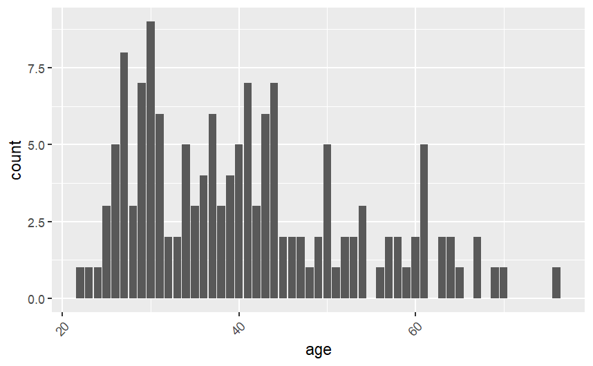

```r
d_age = d %>%
  dplyr::select(participant_id, age, age_cat,gender)
d_age = distinct(d_age)
ggplot(d_age, aes(x = `age`)) +
        geom_bar() +
        theme(axis.text.x = element_text(angle = 45, hjust = 1))
```

```r
# gender stats
table(des$gender)
```

```
female   male  other
    69     76      1
```

```r
table(des$race_eth)
```

```
   Asian    Black Hispanic    Other    White
       5       12        7        1      112
```

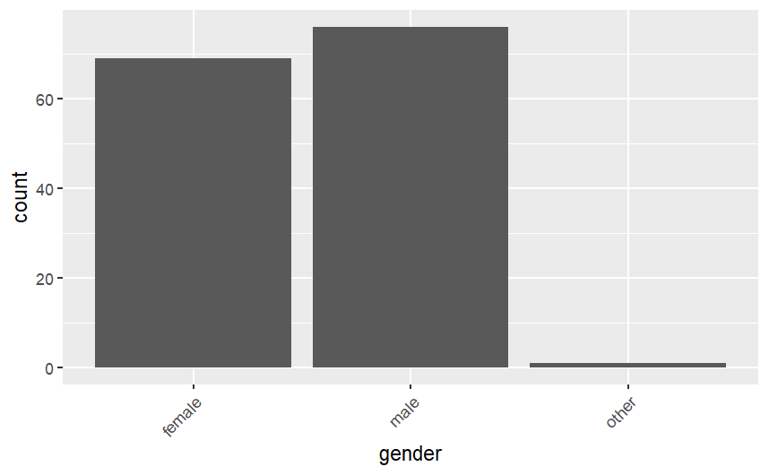

```r
d_gender = d %>%
  dplyr::select(participant_id, age, age_cat,gender)
d_gender = distinct(d_gender)
ggplot(d_gender, aes(x = `gender`)) +
        geom_bar() +
        theme(axis.text.x = element_text(angle = 45, hjust = 1))
```

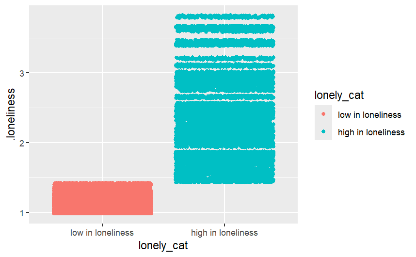

```r
# loneliness stats
ggplot(d, aes(y = .loneliness, color = lonely_cat,
                     fill = lonely_cat, x = lonely_cat)) + geom_point(alpha = 0.3) + geom_jitter()
```

[output not shown]

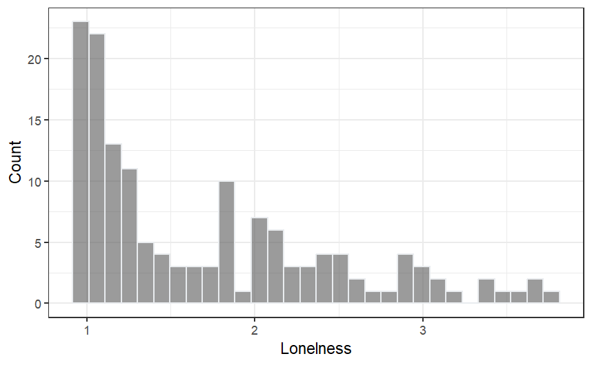

```r
p <- des %>%
  ggplot( aes(x=.loneliness)) +
    theme_bw()+
    geom_histogram( color="#e9ecef", alpha=0.6, , position="dodge") +
    scale_fill_manual(values=c("#69b3a2", "#404080")) +
    #theme_ipsum() +
    labs(x = "Lonelness", y = "Count") ;p
```

```r
median (des$.loneliness)
```

```
[1] 1.4
```

```r
table(des$lonely_cat)
```

```
 low in loneliness high in loneliness
                74                 72
```

```r
sd(des$popularity_ratingappealing)
```

```
[1] 1.366047
```

### H1 Analysis (Are lonely individuals more attracted to popular others)

#### homophily

```r
r = lmer(rating_dist ~ kept + (1|participant_id), data = d); summary(r)
# significant - people tend to choose peers who rate artworks more similarly
```

#### homophily & loneliness

```r
r = glmer(kept ~ rating_dist*.loneliness + (1|participant_id), family = "binomial",data = d); summary(r)
barGraph (d, "rating_dist","lonely_cat","kept","homophily & loneliness", "","rating distance")
```

#### popularity

```r
r = glmer(kept ~ agent_liking + (1|participant_id),family = binomial, data = d); summary(r)
r.squaredGLMM(r)
confint(r)
# graph
lineGraph  (d, "agent_liking","kept","trial","popularity effect", "trials","popularity")
p<-ggplot(data=d, aes(x=kept, y=agent_liking)) +
  geom_bar(stat="identity", fill="steelblue")+
  coord_cartesian(ylim = c(2700000, 2800000)) +
  theme_minimal()
p+ xlab(" ") + ylab("popularity")
```

#### popularity and loneliness (H1)

```r
r = glmer(kept ~ agent_liking*.loneliness + (1|participant_id), family = "binomial",data = d); summary(r)

# significant - the more lonely people are, the more they tend to keep popular peers
r.squaredGLMM(r)
# graph
barGraph  (d, "agent_liking","lonely_cat","kept","popularity & loneliness", "","popularity")

lineGraph (d, "agent_liking","lonely_cat","kept","", "Participant Loneliness","Peer Popularity")
```

### Exploratory Analysis

#### within trial effects

```r
s=d%>%
  filter(kept =="kept")%>%
  #filter(trial <4) %>%
  dplyr::select(participant_id,
         trial,
         agents_names,
         agent_rating,
         kept,
         kept_1_response_liking,
         kept_2_response_liking, kept_3_response_liking,subject_rating, lonely_cat, agent_liking, rating_dist)%>%
  dplyr::group_by(participant_id,trial)%>%
  #mutate(agentNumber = seq(1:3)) %>%
  ungroup()%>%
  dplyr::group_by(participant_id)%>%#, agentNumber)%>%
  arrange(participant_id,trial)


s = s %>%
  #mutate(like_repeat = ifelse(kept_1_response_liking == kept_2_response_liking | kept_1_response_liking == kept_3_response_liking | kept_3_response_liking == kept_2_response_liking, 1,0))%>%
  dplyr::mutate(kept_order = ifelse(agent_liking == kept_1_response_liking, 1, ifelse(agent_liking == kept_2_response_liking, 2,3)))%>%
  dplyr::mutate(kept_order = as.factor(kept_order))

p <- ggplot(s, aes(y = agent_liking, x = trial, color = kept_order)) +
  #geom_point(alpha=0.4) +
  geom_smooth(method='auto')+
  facet_wrap(~lonely_cat)+
    theme_bw()+
    theme(plot.title = element_text(hjust=0.5,size = rel(1.5)),
          axis.title.y = element_text(face="bold",  size=14),
          axis.text.x  = element_text( vjust=0.5, size=12),
          axis.text.y  = element_text( vjust=0.5, size=12),
          axis.title.x = element_text( vjust=0.5, size=18)) +
  xlab("Trial") + ylab("Popularity"); p

barGraph2(s, "agent_liking","kept_order","lonely_cat","within trial", "","popularity")
```

#### correlation between loneliness and other measures

##### lonelinss & my impression of the agent who has more average likes

```r
d_moderate = d %>%
  dplyr::select(.loneliness, pop_agent_popularity, pop_agent_positivity, pop_agent_interesting, pop_agent_like, pop_agent_ratingsimilar, pop_agent_likesimilar)
d_moderate = distinct(d_moderate)
d_cor = rcorr(as.matrix(d_moderate), type=c("pearson"))
a = corrplot(d_cor$r, tl.cex = 0.8, order = "alphabet",p.mat=d_cor$P, insig="blank", method = "color", diag = FALSE, type = "upper",number.cex = 0.8,
         addCoef.col = "black", # Add coefficient of correlation
         tl.col="black")  # Text label color and rotation
```

##### lonelinss & my impression of the agent who has less average likes

```r
d_moderate = d %>%
  dplyr::select(.loneliness, nonpop_agent_popularity, nonpop_agent_positivity, nonpop_agent_interesting, nonpop_agent_like, nonpop_agent_ratingsimilar, nonpop_agent_likesimilar)
d_moderate = distinct(d_moderate)
d_cor = rcorr(as.matrix(d_moderate), type=c("pearson"))
b = corrplot(d_cor$r, tl.cex = 0.8, order = "alphabet",p.mat=d_cor$P, insig="blank", method = "color", diag = FALSE, type = "upper",number.cex = 0.8,
         addCoef.col = "black", # Add coefficient of correlation
         tl.col="black")  # Text label color and rotation
```

##### loneliness & do I see myself as popular

```r
d_moderate = d %>%
  dplyr::select(.loneliness, popularity_selfpopular, popularity_attractpopular, popularity_interetpopular, popularity_wishpopular, popularity_commentpopular, popularity_commentinteresting, popularity_ratingappealing)
d_moderate = distinct(d_moderate)
d_cor = rcorr(as.matrix(d_moderate), type=c("pearson"))
corrplot(d_cor$r, tl.cex = 0.8, order = "alphabet",p.mat=d_cor$P, insig="blank", method = "color", diag = FALSE, type = "upper",number.cex = 0.8,
         addCoef.col = "black", # Add coefficient of correlation
         tl.col="black")  # Text label color and rotation
```

##### attraction to popularity & do I see myself as popular

```r
popularity_cor = d %>%
  dplyr::select(popularity_coef, popularity_selfpopular, popularity_attractpopular, popularity_interetpopular, popularity_wishpopular, popularity_commentpopular, popularity_commentinteresting, popularity_ratingappealing)
d_cor = rcorr(as.matrix(popularity_cor), type=c("pearson"))
corrplot(d_cor$r, tl.cex = 0.8, order = "alphabet",p.mat=d_cor$P, insig="blank", method = "color", diag = FALSE, type = "upper",number.cex = 0.8,
         addCoef.col = "black", # Add coefficient of correlation
         tl.col="black")  # Text label color and rotation
```

##### attraction to popularity & my impression of the agent who has more average likes

```r
popularity_cor = d %>%
  dplyr::select(popularity_coef, pop_agent_popularity, pop_agent_positivity, pop_agent_interesting, pop_agent_like, pop_agent_ratingsimilar, pop_agent_likesimilar)
d_cor = rcorr(as.matrix(popularity_cor), type=c("pearson"))
corrplot(d_cor$r, tl.cex = 0.8, order = "alphabet",p.mat=d_cor$P, insig="blank", method = "color", diag = FALSE, type = "upper",number.cex = 0.8,
         addCoef.col = "black", # Add coefficient of correlation
         tl.col="black")  # Text label color and rotation
```

##### attraction to popularity & my impression of the agent who has less average likes

```r
popularity_cor = d %>%
  dplyr::select(popularity_coef, nonpop_agent_popularity, nonpop_agent_positivity, nonpop_agent_interesting, nonpop_agent_like, nonpop_agent_ratingsimilar, nonpop_agent_likesimilar)
d_cor = rcorr(as.matrix(popularity_cor), type=c("pearson"))
corrplot(d_cor$r, tl.cex = 0.8, order = "alphabet",p.mat=d_cor$P, insig="blank", method = "color", diag = FALSE, type = "upper",number.cex = 0.8,
         addCoef.col = "black", # Add coefficient of correlation
         tl.col="black")  # Text label color and rotation
```

##### combined correlation

```r
# general correlation
d_moderate = d %>%
  dplyr::select(.loneliness, popularity_coef, pop_agent_popularity, pop_agent_positivity, pop_agent_interesting, pop_agent_like, pop_agent_ratingsimilar, pop_agent_likesimilar, nonpop_agent_popularity, nonpop_agent_positivity, nonpop_agent_interesting, nonpop_agent_like, nonpop_agent_ratingsimilar, nonpop_agent_likesimilar, popularity_selfpopular, popularity_attractpopular, popularity_interetpopular, popularity_wishpopular, popularity_commentpopular, popularity_commentinteresting, popularity_ratingappealing)
d_moderate = distinct(d_moderate)
d_cor = rcorr(as.matrix(d_moderate), type=c("pearson"))
format_cor = function(cor, p) {
  stars = ifelse(p < 0.001, "***", ifelse(p < 0.01, "**", ifelse(p < 0.05, "*", "")))
  formatted = sprintf("%.2f%s", cor, stars)
  formatted[formatted == "1.00"] = ""  # Remove diagonal
  return(formatted)
}
cor_matrix = matrix(format_cor(d_cor$r, d_cor$P), nrow=21)
colnames(cor_matrix) = rownames(cor_matrix) = colnames(d_moderate)
cor_table = as.data.frame(cor_matrix)
cor_table = cbind(Variable = rownames(cor_table), cor_table)
kable(cor_table, format = "markdown", caption = "Correlation Matrix", align = 'c')
#write.csv(cor_table, "correlation_table.csv", row.names = FALSE)

means = sapply(d_moderate, mean, na.rm = TRUE)
sds = sapply(d_moderate, sd, na.rm = TRUE)

# Add means and SDs to the correlation table
cor_table = cor_table %>%
  dplyr::mutate(
    Variable = rownames(cor_table),
    Mean = sprintf("%.2f", means),
    SD = sprintf("%.2f", sds)
  ) %>%
  dplyr::select(Variable, Mean, SD, everything())

# Save as CSV
#write.csv(cor_table, "correlation_table_with_means_sds.csv", row.names = FALSE)
```

#### mediation analysis

```r
# List of mediators
mediators <- c(
  "popularity_selfpopular",
  "popularity_commentpopular",
  "popularity_commentinteresting",
  "popularity_wishpopular",
  "pop_agent_ratingsimilar",
  "pop_agent_likesimilar"
)
med_model <- lm(popularity_selfpopular ~ .loneliness, data = d)
# Fit the outcome model
out_model <- lm(popularity_coef ~ .loneliness + popularity_selfpopular, data = d)
# Run the mediation analysis with bootstrapping
med_result <- mediate(med_model, out_model, treat = ".loneliness", mediator = "popularity_selfpopular", boot = TRUE, sims = 5000)
summary(med_result)

med_model <- lm(pop_agent_ratingsimilar ~ .loneliness, data = d)
# Fit the outcome model
out_model <- lm(popularity_coef ~ .loneliness + pop_agent_ratingsimilar, data = d)
# Run the mediation analysis with bootstrapping
med_result <- mediate(med_model, out_model, treat = ".loneliness", mediator = "pop_agent_ratingsimilar", boot = TRUE, sims = 5000)
summary(med_result)

med_model <- lm(pop_agent_likesimilar ~ .loneliness, data = d)
# Fit the outcome model
out_model <- lm(popularity_coef ~ .loneliness + pop_agent_likesimilar, data = d)
# Run the mediation analysis with bootstrapping
med_result <- mediate(med_model, out_model, treat = ".loneliness", mediator = "pop_agent_likesimilar", boot = TRUE, sims = 5000)
summary(med_result)

med_model <- lm(nonpop_agent_ratingsimilar ~ .loneliness, data = d)
# Fit the outcome model
out_model <- lm(popularity_coef ~ .loneliness + nonpop_agent_ratingsimilar, data = d)
# Run the mediation analysis with bootstrapping
med_result <- mediate(med_model, out_model, treat = ".loneliness", mediator = "nonpop_agent_ratingsimilar", boot = TRUE, sims = 5000)
summary(med_result)

med_model <- lm(nonpop_agent_likesimilar ~ .loneliness, data = d)
# Fit the outcome model
out_model <- lm(popularity_coef ~ .loneliness + nonpop_agent_likesimilar, data = d)
# Run the mediation analysis with bootstrapping
med_result <- mediate(med_model, out_model, treat = ".loneliness", mediator = "nonpop_agent_likesimilar", boot = TRUE, sims = 5000)
summary(med_result)

med_model <- lm(popularity_wishpopular ~ .loneliness, data = d)
# Fit the outcome model
out_model <- lm(popularity_coef ~ .loneliness + popularity_wishpopular, data = d)
# Run the mediation analysis with bootstrapping
med_result <- mediate(med_model, out_model, treat = ".loneliness", mediator = "popularity_wishpopular", boot = TRUE, sims = 5000)
summary(med_result)
```

##### attractive to popularity coefficient & do i see myself as popular

```r
## lonely & attractive to popularity coefficient & do i see myself as popular
r = lmer(popularity_coef ~ popularity_selfpopular * .loneliness + (1|participant_id), data = d); summary(r)
r = lmer(popularity_coef ~ .loneliness * popularity_selfpopular + (1|participant_id), data = d); summary(r)
# SIG
lineGraph (d, "popularity_coef","lonely_cat","popularity_selfpopular","", "How much do I see myself as popular", "Coefficient of attractiveness to popularity")
ggplot(d, aes(x = popularity_selfpopular, y = popularity_coef, color = lonely_cat, fill = lonely_cat))+
  geom_point(alpha = 0.3) +
  geom_smooth(method=lm, se=FALSE)
```

##### attractive to popularity coefficient & to what extent are you interested in popular people

```r
r = lmer(popularity_coef ~ popularity_interetpopular + (1|participant_id), data = d); summary(r)
# SIG
ggplot(d, aes(x = popularity_interetpopular, y = popularity_coef)) +
  geom_point(alpha = 0.7) +
  geom_smooth(method=lm, se=FALSE)

## lonely
r = lmer(popularity_coef ~ popularity_interetpopular * .loneliness + (1|participant_id), data = d); summary(r)
# SIG
lineGraph (d, "popularity_coef","lonely_cat","popularity_interetpopular","", "Am I interested in popular people", "Coefficient of attractiveness to popularity")
ggplot(d, aes(x = popularity_interetpopular, y = popularity_coef, color = lonely_cat, fill = lonely_cat))+
  geom_point(alpha = 0.3) +
  geom_smooth(method=lm, se=FALSE)
```

### Power Analysis

```r
set.seed(2532)

d$participant_id <- as.factor(d$participant_id)
PowerModel = glmer(kept ~ agent_liking * .loneliness + (1|participant_id),
                  family=binomial, data=d,
                  control=glmerControl(optimizer="bobyqa"))
```

```
boundary (singular) fit: see help('isSingular')
```

```r
extended_model <- extend(PowerModel, along="participant_id", n=300)
pc <- powerCurve(extended_model,
                test = fixed("agent_liking:.loneliness"),
                nsim = 200,
                along = "participant_id")
```

```
Calculating power at 10 sample sizes along participant_id
```

[output not shown]

[output not shown]

[output not shown]

[output not shown]

[output not shown]

[output not shown]

[output not shown]

[output not shown]

[output not shown]

[output not shown]

[output not shown]

[output not shown]

[output not shown]

[output not shown]

[output not shown]

[output not shown]

[output not shown]

[output not shown]

[output not shown]

[output not shown]

[output not shown]

[output not shown]

[output not shown]

[output not shown]

[output not shown]

[output not shown]

[output not shown]

[output not shown]

[output not shown]

[output not shown]

[output not shown]

[output not shown]

[output not shown]

[output not shown]

[output not shown]

[output not shown]

[output not shown]

[output not shown]

[output not shown]

[output not shown]

[output not shown]

[output not shown]

[output not shown]

[output not shown]

[output not shown]

[output not shown]

[output not shown]

[output not shown]

[output not shown]

[output not shown]

[output not shown]

[output not shown]

[output not shown]

[output not shown]

[output not shown]

[output not shown]

[output not shown]

[output not shown]

[output not shown]

[output not shown]

[output not shown]

[output not shown]

[output not shown]

[output not shown]

[output not shown]

[output not shown]

[output not shown]

[output not shown]

[output not shown]

[output not shown]

[output not shown]

[output not shown]

[output not shown]

[output not shown]

[output not shown]

[output not shown]

[output not shown]

[output not shown]

[output not shown]

[output not shown]

[output not shown]

[output not shown]

[output not shown]

[output not shown]

[output not shown]

[output not shown]

[output not shown]

[output not shown]

[output not shown]

[output not shown]

[output not shown]

[output not shown]

[output not shown]

[output not shown]

[output not shown]

[output not shown]

[output not shown]

[output not shown]

[output not shown]

[output not shown]

[output not shown]

[output not shown]

[output not shown]

[output not shown]

[output not shown]

[output not shown]

[output not shown]

[output not shown]

[output not shown]

[output not shown]

[output not shown]

[output not shown]

[output not shown]

[output not shown]

[output not shown]

[output not shown]

[output not shown]

[output not shown]

[output not shown]

[output not shown]

[output not shown]

[output not shown]

[output not shown]

[output not shown]

[output not shown]

[output not shown]

[output not shown]

[output not shown]

[output not shown]

[output not shown]

[output not shown]

[output not shown]

[output not shown]

[output not shown]

[output not shown]

[output not shown]

[output not shown]

[output not shown]

[output not shown]

[output not shown]

[output not shown]

[output not shown]

[output not shown]

[output not shown]

[output not shown]

[output not shown]

[output not shown]

[output not shown]

[output not shown]

[output not shown]

[output not shown]

[output not shown]

[output not shown]

[output not shown]

[output not shown]

[output not shown]

[output not shown]

[output not shown]

[output not shown]

[output not shown]

[output not shown]

[output not shown]

[output not shown]

[output not shown]

[output not shown]

[output not shown]

[output not shown]

[output not shown]

[output not shown]

[output not shown]

[output not shown]

[output not shown]

[output not shown]

[output not shown]

[output not shown]

[output not shown]

[output not shown]

[output not shown]

[output not shown]

[output not shown]

[output not shown]

[output not shown]

[output not shown]

[output not shown]

[output not shown]

[output not shown]

[output not shown]

[output not shown]

[output not shown]

[output not shown]

[output not shown]

[output not shown]

[output not shown]

[output not shown]

[output not shown]

[output not shown]

[output not shown]

[output not shown]

[output not shown]

[output not shown]

[output not shown]

[output not shown]

[output not shown]

[output not shown]

[output not shown]

[output not shown]

[output not shown]

[output not shown]

[output not shown]

[output not shown]

[output not shown]

[output not shown]

[output not shown]

[output not shown]

[output not shown]

[output not shown]

[output not shown]

[output not shown]

[output not shown]

[output not shown]

[output not shown]

[output not shown]

[output not shown]

[output not shown]

[output not shown]

[output not shown]

[output not shown]

[output not shown]

[output not shown]

[output not shown]

[output not shown]

[output not shown]

[output not shown]

[output not shown]

[output not shown]

[output not shown]

[output not shown]

[output not shown]

[output not shown]

[output not shown]

[output not shown]

[output not shown]

[output not shown]

[output not shown]

[output not shown]

[output not shown]

[output not shown]

[output not shown]

[output not shown]

[output not shown]

[output not shown]

[output not shown]

[output not shown]

[output not shown]

[output not shown]

[output not shown]

[output not shown]

[output not shown]

[output not shown]

[output not shown]

[output not shown]

[output not shown]

[output not shown]

[output not shown]

[output not shown]

[output not shown]

[output not shown]

[output not shown]

[output not shown]

[output not shown]

[output not shown]

[output not shown]

[output not shown]

[output not shown]

[output not shown]

[output not shown]

[output not shown]

[output not shown]

[output not shown]

[output not shown]

[output not shown]

[output not shown]

[output not shown]

[output not shown]

[output not shown]

[output not shown]

[output not shown]

[output not shown]

[output not shown]

[output not shown]

[output not shown]

[output not shown]

[output not shown]

[output not shown]

[output not shown]

[output not shown]

[output not shown]

[output not shown]

[output not shown]

[output not shown]

[output not shown]

[output not shown]

[output not shown]

[output not shown]

[output not shown]

[output not shown]

[output not shown]

[output not shown]

[output not shown]

[output not shown]

[output not shown]

[output not shown]

[output not shown]

[output not shown]

[output not shown]

[output not shown]

[output not shown]

[output not shown]

[output not shown]

[output not shown]

[output not shown]

[output not shown]

[output not shown]

[output not shown]

[output not shown]

[output not shown]

[output not shown]

[output not shown]

[output not shown]

[output not shown]

[output not shown]

[output not shown]

[output not shown]

[output not shown]

[output not shown]

[output not shown]

[output not shown]

[output not shown]

[output not shown]

[output not shown]

[output not shown]

[output not shown]

[output not shown]

[output not shown]

[output not shown]

[output not shown]

[output not shown]

[output not shown]

[output not shown]

[output not shown]

[output not shown]

[output not shown]

[output not shown]

[output not shown]

[output not shown]

[output not shown]

[output not shown]

[output not shown]

[output not shown]

[output not shown]

[output not shown]

[output not shown]

[output not shown]

[output not shown]

[output not shown]

[output not shown]

[output not shown]

[output not shown]

[output not shown]

[output not shown]

[output not shown]

[output not shown]

[output not shown]

[output not shown]

[output not shown]

[output not shown]

[output not shown]

[output not shown]

[output not shown]

[output not shown]

[output not shown]

[output not shown]

[output not shown]

[output not shown]

[output not shown]

[output not shown]

[output not shown]

[output not shown]

[output not shown]

[output not shown]

[output not shown]

[output not shown]

[output not shown]

[output not shown]

[output not shown]

[output not shown]

[output not shown]

[output not shown]

[output not shown]

[output not shown]

[output not shown]

[output not shown]

[output not shown]

[output not shown]

[output not shown]

[output not shown]

[output not shown]

[output not shown]

[output not shown]

[output not shown]

[output not shown]

[output not shown]

[output not shown]

[output not shown]

[output not shown]

[output not shown]

[output not shown]

[output not shown]

[output not shown]

[output not shown]

[output not shown]

[output not shown]

[output not shown]

[output not shown]

[output not shown]

[output not shown]

[output not shown]

[output not shown]

[output not shown]

[output not shown]

[output not shown]

[output not shown]

[output not shown]

[output not shown]

[output not shown]

[output not shown]

[output not shown]

[output not shown]

[output not shown]

[output not shown]

[output not shown]

[output not shown]

[output not shown]

[output not shown]

[output not shown]

[output not shown]

[output not shown]

[output not shown]

[output not shown]

[output not shown]

[output not shown]

[output not shown]

[output not shown]

[output not shown]

[output not shown]

[output not shown]

[output not shown]

[output not shown]

[output not shown]

[output not shown]

[output not shown]

[output not shown]

[output not shown]

[output not shown]

[output not shown]

[output not shown]

[output not shown]

[output not shown]

[output not shown]

[output not shown]

[output not shown]

[output not shown]

[output not shown]

[output not shown]

[output not shown]

[output not shown]

[output not shown]

[output not shown]

[output not shown]

[output not shown]

[output not shown]

[output not shown]

[output not shown]

[output not shown]

[output not shown]

[output not shown]

[output not shown]

[output not shown]

[output not shown]

[output not shown]

[output not shown]

[output not shown]

[output not shown]

[output not shown]

[output not shown]

[output not shown]

[output not shown]

[output not shown]

[output not shown]

[output not shown]

[output not shown]

[output not shown]

[output not shown]

[output not shown]

[output not shown]

[output not shown]

[output not shown]

[output not shown]

[output not shown]

[output not shown]

[output not shown]

[output not shown]

[output not shown]

[output not shown]

[output not shown]

[output not shown]

[output not shown]

[output not shown]

[output not shown]

[output not shown]

[output not shown]

[output not shown]

[output not shown]

[output not shown]

[output not shown]

[output not shown]

[output not shown]

[output not shown]

[output not shown]

[output not shown]

[output not shown]

[output not shown]

[output not shown]

[output not shown]

[output not shown]

[output not shown]

[output not shown]

[output not shown]

[output not shown]

[output not shown]

[output not shown]

```r
pc
```

```
Power for predictor 'agent_liking:.loneliness', (95% confidence interval),
by number of levels in participant_id:
      3:  6.00% ( 3.14, 10.25) - 540 rows
     36: 13.00% ( 8.67, 18.47) - 6480 rows
     69: 34.00% (27.47, 41.02) - 12420 rows
    102: 38.50% (31.72, 45.62) - 18360 rows
    135: 50.00% (42.87, 57.13) - 24300 rows
    168: 63.50% (56.42, 70.18) - 30240 rows
    201: 67.00% (60.02, 73.47) - 36180 rows
    234: 76.50% (70.00, 82.19) - 42120 rows
    267: 80.50% (74.32, 85.75) - 48060 rows
    300: 86.00% (80.41, 90.49) - 54000 rows

Time elapsed: 1 h 39 m 49 s
```

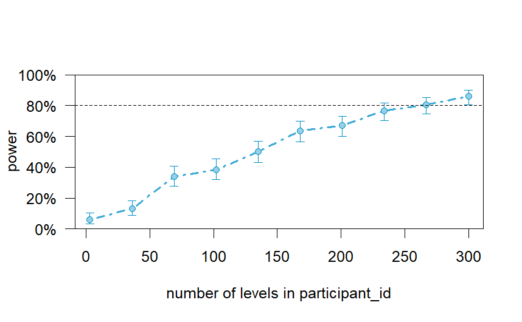

```r
#Power for predictor 'agent_liking:.loneliness', (95% confidence interval),
#by number of levels in participant_id:
#      3:  4.00% ( 1.74,  7.73) - 540 rows
#     36: 13.00% ( 8.67, 18.47) - 6480 rows
#     69: 25.50% (19.61, 32.13) - 12420 rows
#    102: 30.50% (24.20, 37.39) - 18360 rows
#    135: 45.00% (37.98, 52.18) - 24300 rows
#    168: 54.50% (47.33, 61.54) - 30240 rows
#    201: 66.50% (59.50, 73.00) - 36180 rows
#    234: 73.00% (66.28, 79.02) - 42120 rows
#    267: 75.00% (68.40, 80.84) - 48060 rows
#    300: 79.50% (73.23, 84.87) - 54000 rows
plot(pc)
```